← All notes Source: `08_autoencoder_explained.ipynb`

Get the notebook ↓ Download .ipynb [▶ Open in Colab](https://colab.research.google.com/github/shammun/shammunul-fastai-notes/blob/main/notebooks/08_autoencoder_explained_colab.ipynb)

# Notebook 08: Autoencoders - Learning to Compress and Reconstruct

## What This Notebook Covers

This notebook introduces **Autoencoders**, a type of neural network that learns to compress data into a smaller representation and then reconstruct it. We will learn:

1. **What is an Autoencoder?** - The concept and architecture
2. **Why use Autoencoders?** - Applications and use cases
3. **Fashion MNIST Dataset** - Loading and exploring the data
4. **CNN Classification (Warmup)** - Review of convolutional networks
5. **Building an Autoencoder** - Encoder and Decoder design
6. **Deconvolution (Upsampling)** - How to increase image size
7. **Training and Evaluation** - MSE loss for reconstruction

## What is an Autoencoder?

An **Autoencoder** is a neural network that learns to:

1. **Encode**: Compress input data into a smaller representation (called the **latent space** or **bottleneck**)
2. **Decode**: Reconstruct the original input from this compressed representation

```
Input Image          Encoder          Latent Space         Decoder         Reconstructed Image
   28×28      →    [Compress]    →      Small       →    [Expand]     →        28×28
   784 pixels      (CNN layers)      (e.g., 64 values)   (Deconv layers)      784 pixels
```

**The key insight:** The network is forced to learn the most important features of the data because it must squeeze everything through a small bottleneck!

## Why Use Autoencoders?

| Application | How It Works |
| --- | --- |
| **Dimensionality Reduction** | The latent space is a compressed representation |
| **Denoising** | Train on noisy inputs, reconstruct clean outputs |
| **Anomaly Detection** | Unusual inputs have high reconstruction error |
| **Feature Learning** | The encoder learns useful representations |
| **Generative Models** | Variational Autoencoders (VAEs) can generate new data |

## 🎬 Interactive Visualizations in This Notebook

This notebook now includes **six hands-on interactive visualizations** that you can click, drag, step through, and play. Each one targets a concept that is much easier to *see* than to read about:

| # | Visualization | What it makes clear |
| --- | --- | --- |
| 1 | **Autoencoder Pipeline Explorer** | The whole squeeze-then-rebuild story end to end, with the 784 → 256 → 784 value counts |
| 2 | **Convolution Stride Lab** | How `stride=2` halves the image and how filters create channels |
| 3 | **Deconv Upsample Lab** | The two-step `upsample → conv` recipe, plus the checkerboard problem |
| 4 | **"Same" Padding Playground** | Why `padding = ks//2` keeps the spatial size identical |
| 5 | **3D Architecture Hourglass** | The tensor volumes shrinking and expanding in 3D (drag to rotate) |
| 6 | **Latent Space Explorer** | Dragging through the compressed code and watching reconstructions morph |

Most have **clickable stages**, a **speed slider**, **Play/Step** controls, and a **code panel** that updates to show the exact line running at each stage. Just run the cell beneath each section. *(They are self-contained and work offline.)*

### 🔍 Visualize It: The Full Autoencoder Pipeline

Before any code, here is the big picture. Step through the five stages (or press **Play**) to watch an image get squeezed through the bottleneck and rebuilt. Click any stage on the rail to jump to it and see the code for that stage.

```python
# ============================================================================
# INTERACTIVE VISUALIZATION (self-contained) -- run this cell.
# End-to-end: Input -> Encoder -> Bottleneck -> Decoder -> Output, with live value counts.
# The widget lives in the separate file `ae_pipeline_explorer.html`; it is embedded here as a
# base64 data-URI iframe, so the notebook stays fully self-contained and works
# offline in Jupyter, Colab, VS Code, and the exported HTML. The iframe
# broadcasts its own content height, and the listener below resizes it to fit
# exactly -- full width, wrapped to content, with no empty space below.
# ============================================================================
```

[interactive chart not shown]

# Part 1: Setup and Imports

First, let's import all the libraries we need.

```python
# =====================================================
# STANDARD PYTHON LIBRARIES
# =====================================================

import pickle          # For loading/saving Python objects
import gzip            # For compressed files
import math            # Mathematical functions
import os              # Operating system interface
import time            # Timing operations
import shutil          # File operations

# =====================================================
# DATA SCIENCE LIBRARIES
# =====================================================

import numpy as np                    # Numerical computing
import matplotlib as mpl              # Plotting configuration
import matplotlib.pyplot as plt       # Creating plots

# =====================================================
# PYTORCH LIBRARIES
# =====================================================

import torch                          # Main PyTorch library
from torch import tensor, nn, optim   # Tensors, neural networks, optimizers
from torch.utils.data import DataLoader, default_collate  # Data loading utilities
import torch.nn.functional as F       # Functional operations (loss functions, etc.)
import torchvision.transforms.functional as TF  # Image transformations

# =====================================================
# HUGGING FACE DATASETS
# =====================================================

# datasets is a library from Hugging Face that provides easy access
# to many popular datasets, including Fashion MNIST
from datasets import load_dataset, load_dataset_builder

# =====================================================
# UTILITY LIBRARIES
# =====================================================

from pathlib import Path              # Modern path handling
from operator import attrgetter, itemgetter  # Efficient attribute/item access
from functools import partial         # Partial function application
from collections.abc import Mapping   # For type checking dictionaries

# =====================================================
# FASTAI UTILITIES (from previous notebooks)
# =====================================================

# These are helper functions from the fastai library and our miniai module
import fastcore.all as fc
from fastcore.test import test_close  # Testing utility
from fastprogress import progress_bar, master_bar  # Progress bars
```

```python
# =====================================================
# CONFIGURATION AND SETTINGS
# =====================================================

# Set how PyTorch displays tensors:
#   precision=2     - Show 2 decimal places
#   linewidth=140   - Wider lines before wrapping
#   sci_mode=False  - Don't use scientific notation
torch.set_printoptions(precision=2, linewidth=140, sci_mode=False)

# Set random seed for reproducibility
# This ensures we get the same "random" results each time
torch.manual_seed(1)

# Use grayscale colormap for images (Fashion MNIST is black and white)
mpl.rcParams['image.cmap'] = 'gray'

# Disable warning messages from the datasets library
import logging
logging.disable(logging.WARNING)
```

```python
# =====================================================
# DEVICE SELECTION (GPU IF AVAILABLE)
# =====================================================

# Choose the best available device:
#   - MPS: Apple Silicon GPU (M1/M2 Macs)
#   - CUDA: NVIDIA GPU
#   - CPU: Fallback if no GPU available

if torch.backends.mps.is_available():
    def_device = 'mps'
elif torch.cuda.is_available():
    def_device = 'cuda'
else:
    def_device = 'cpu'

print(f"Using device: {def_device}")
```

```
Using device: cuda
```

```python
# =====================================================
# HELPER FUNCTIONS (from previous notebooks)
# =====================================================

def to_device(x, device=def_device):
    """
    Move a tensor or collection of tensors to the specified device.

    Arguments:
        x      - A tensor, dictionary, or iterable of tensors
        device - The target device ('cuda', 'mps', or 'cpu')

    Returns:
        The same structure with all tensors moved to the device
    """
    if isinstance(x, torch.Tensor):
        return x.to(device)
    if isinstance(x, Mapping):
        return {k: v.to(device) for k, v in x.items()}
    return type(x)(to_device(o, device) for o in x)


def conv(ni, nf, ks=3, stride=2, act=True):
    """
    Create a convolution layer with optional ReLU activation.

    This is the same helper function from the convolutions notebook.

    Arguments:
        ni     - Number of input channels
        nf     - Number of output channels (filters)
        ks     - Kernel size (default 3 for 3x3)
        stride - Stride (default 2 to halve spatial size)
        act    - Whether to add ReLU activation (default True)

    Returns:
        A Conv2d layer, optionally wrapped with ReLU
    """
    res = nn.Conv2d(ni, nf, stride=stride, kernel_size=ks, padding=ks//2)
    if act:
        res = nn.Sequential(res, nn.ReLU())
    return res


def show_image(im, ax=None, figsize=(3,3), title=None, noframe=True, cmap=None):
    """Display a single image."""
    if ax is None:
        fig, ax = plt.subplots(figsize=figsize)
    if hasattr(im, 'cpu'):
        im = im.detach().cpu()
    if hasattr(im, 'numpy'):
        im = im.numpy()
    if im.ndim == 3 and im.shape[0] in [1, 3]:
        im = im.transpose(1, 2, 0)
    if im.ndim == 3 and im.shape[2] == 1:
        im = im[:, :, 0]
    ax.imshow(im, cmap=cmap)
    if title is not None:
        ax.set_title(title)
    if noframe:
        ax.axis('off')
    return ax


def show_images(ims, nrows=1, ncols=None, titles=None, figsize=None, imsize=3):
    """Display multiple images in a grid."""
    if ncols is None:
        ncols = len(ims)
    if figsize is None:
        figsize = (ncols * imsize, nrows * imsize)
    fig, axes = plt.subplots(nrows, ncols, figsize=figsize)
    if nrows * ncols == 1:
        axes = [axes]
    else:
        axes = axes.flatten()
    for i, (im, ax) in enumerate(zip(ims, axes)):
        title = titles[i] if titles else None
        show_image(im, ax=ax, title=title)
    plt.tight_layout()
    return fig
```

# Part 2: Loading the Fashion MNIST Dataset

## What is Fashion MNIST?

**Fashion MNIST** is a dataset of clothing images, designed as a drop-in replacement for the classic MNIST digit dataset. It's more challenging while having the same format:

- **60,000 training images** and **10,000 test images**
- **28 × 28 pixels** each, grayscale
- **10 classes** of clothing items

| Label | Description |
| --- | --- |
| 0 | T-shirt/top |
| 1 | Trouser |
| 2 | Pullover |
| 3 | Dress |
| 4 | Coat |
| 5 | Sandal |
| 6 | Shirt |
| 7 | Sneaker |
| 8 | Bag |
| 9 | Ankle boot |

```python
# =====================================================
# LOADING FASHION MNIST WITH HUGGING FACE DATASETS
# =====================================================

# Define the column names in the dataset
x = 'image'   # The column containing images
y = 'label'   # The column containing labels (0-9)

# Name of the dataset on Hugging Face
name = "fashion_mnist"

# load_dataset downloads and caches the dataset
# ignore_verifications=True skips hash verification (faster loading)
#
# Returns a DatasetDict with 'train' and 'test' splits
dsd = load_dataset(name, ignore_verifications=True)

print(f"Dataset loaded: {name}")
print(f"Splits available: {list(dsd.keys())}")
print(f"Training samples: {len(dsd['train'])}")
print(f"Test samples: {len(dsd['test'])}")
```

[output not shown]

```python
# Let's look at what one sample looks like
sample = dsd['train'][0]
print("Sample structure:")
print(f"  Keys: {sample.keys()}")
print(f"  Image type: {type(sample['image'])}")
print(f"  Label: {sample['label']}")
```

```
Sample structure:
  Keys: dict_keys(['image', 'label'])
  Image type: <class 'PIL.PngImagePlugin.PngImageFile'>
  Label: 9
```

```python
dsd['train']
```

```
Dataset({
    features: ['image', 'label'],
    num_rows: 60000
})
```

## Transforming the Data

The images come as PIL Image objects. We need to convert them to PyTorch tensors for training.

```python
# =====================================================
# DEFINING THE TRANSFORMATION
# =====================================================

# The @inplace decorator modifies the input dictionary directly
# instead of returning a new one. This saves memory.
#
# If you don't have the inplace decorator, you can define it:
def inplace(f):
    """Decorator that makes a function modify its argument in place."""
    def wrapper(b):
        f(b)
        return b
    return wrapper

@inplace
def transformi(b):
    """
    Transform a batch of data by converting images to tensors.

    Arguments:
        b - A dictionary with 'image' key containing PIL Images

    Modifies b in place:
        - Converts each PIL Image to a PyTorch tensor
        - Tensor values are scaled to [0, 1] range
        - Shape becomes (1, 28, 28) - 1 channel, 28x28 pixels

    TF.to_tensor does several things:
        1. Converts PIL Image to PyTorch tensor
        2. Rearranges from (H, W, C) to (C, H, W)
        3. Scales pixel values from [0, 255] to [0.0, 1.0]
    """
    b[x] = [TF.to_tensor(o) for o in b[x]]
```

```python
# =====================================================
# APPLYING THE TRANSFORMATION
# =====================================================

# Batch size - how many samples to process at once
bs = 256

# with_transform applies our transformation lazily (when data is accessed)
# This is memory-efficient: images are converted only when needed
tds = dsd.with_transform(transformi)

print("Transformed dataset created.")
print("Transformation will be applied when data is accessed.")
```

```
Transformed dataset created.
Transformation will be applied when data is accessed.
```

```
Image type: <class 'torch.Tensor'>
Image shape: torch.Size([1, 28, 28])
  - 1 channel (grayscale)
  - 28x28 pixels
Pixel value range: 0.00 to 1.00
```

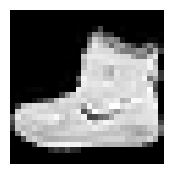

```python
# =====================================================
# EXAMINING A TRANSFORMED SAMPLE
# =====================================================

# Get the training split
ds = tds['train']

# Get the first image (now it's a tensor!)
img = ds[0]['image']

print(f"Image type: {type(img)}")
print(f"Image shape: {img.shape}")
print(f"  - {img.shape[0]} channel (grayscale)")
print(f"  - {img.shape[1]}x{img.shape[2]} pixels")
print(f"Pixel value range: {img.min():.2f} to {img.max():.2f}")

# Display the image
show_image(img, figsize=(2, 2))
```

## Creating Data Loaders

Data loaders batch the data and handle shuffling for training.

```python
# =====================================================
# COLLATE FUNCTION
# =====================================================

# A collate function takes a list of samples and combines them into a batch.
#
# The Hugging Face dataset returns dictionaries like:
#   {'image': tensor, 'label': int}
#
# We need to:
#   1. Stack all images into a single tensor
#   2. Stack all labels into a single tensor
#   3. Move everything to the GPU

def collate_dict(ds):
    """
    Create a collate function for dictionary-based datasets.

    Returns a function that:
        1. Extracts 'image' and 'label' from each sample
        2. Stacks them into batch tensors
    """
    def _collate(batch):
        # Stack all images: list of (1,28,28) -> (batch_size, 1, 28, 28)
        images = torch.stack([b['image'] for b in batch])
        # Stack all labels: list of ints -> (batch_size,)
        labels = torch.tensor([b['label'] for b in batch])
        return images, labels
    return _collate

# Create the collate function for our dataset
cf = collate_dict(ds)
```

### Understanding the Collate Function: Closure Pattern

#### What happens with `cf = collate_dict(ds)`?

`collate_dict` is **already defined** — calling it doesn't *create* the function. Instead, it **calls** `collate_dict`, which **returns the inner function `_collate`**.

So after this line, `cf` **is** the `_collate` function itself — it's a **function object**, not a computed result.

```
cf = collate_dict(ds)
# cf IS _collate — it's a callable function, not a data result
```

> **Note:** In the current implementation, the `ds` argument isn't actually used inside `_collate`. It's likely there for future flexibility or was used in an earlier version of the code.

#### What happens with `cf(b)` inside `collate_`?

Since `cf` *is* the `_collate` function, calling `cf(b)` is identical to calling `_collate(b)`:

1. It takes a **batch** `b` — a list of dictionaries like `[{'image': tensor, 'label': int}, ...]`
2. It **stacks** all images into a single tensor of shape `(batch_size, 1, 28, 28)`
3. It **stacks** all labels into a single tensor of shape `(batch_size,)`
4. It returns the tuple `(images, labels)`

The full chain inside `collate_(b)` works like this:

```
b (list of dicts)
    │
    ▼
cf(b)  →  _collate(b)  →  (stacked_images, stacked_labels)
    │
    ▼
to_device(...)  →  moves both tensors to GPU
    │
    ▼
returns (images_on_gpu, labels_on_gpu)
```

#### Why This Pattern? — The Factory Function

This is a **factory function** (also called a **closure**) — a function that **builds and returns another function**.

**Why is it useful here?**

PyTorch's `DataLoader` expects a collate function with the signature `collate(batch)` — just **one argument**. By wrapping the logic inside a factory:

- You can **bake in configuration** (like dataset structure, column names, etc.) at creation time
- You still hand the `DataLoader` a **clean, single-argument function** that it knows how to call

```
# Factory creates a configured function
cf = collate_dict(ds)        # returns _collate, configured for dict-based datasets

# That function is then used inside another function
def collate_(b):
    return to_device(cf(b))  # stack into batch → move to GPU

# DataLoader only sees a simple collate_(batch) signature
dl = DataLoader(dataset, collate_fn=collate_)
```

This is a common and elegant pattern in Python for **composing behavior** while keeping interfaces clean.

```python
# =====================================================
# DATA LOADERS WITH DEVICE TRANSFER
# =====================================================

def collate_(b):
    """
    Collate function that also moves data to the device (GPU).

    Combines cf (which stacks samples) with to_device (which moves to GPU).
    """
    return to_device(cf(b))


def data_loaders(dsd, bs, **kwargs):
    """
    Create DataLoaders for all splits in a dataset dict.

    Arguments:
        dsd    - A DatasetDict with 'train', 'test', etc.
        bs     - Batch size
        kwargs - Additional arguments for DataLoader

    Returns:
        A dictionary of DataLoaders, one per split
    """
    return {k: DataLoader(v, bs, **kwargs) for k, v in dsd.items()}
```

# Understanding `data_loaders`: Creating DataLoaders from a DatasetDict

## What does this function do?

A Hugging Face `DatasetDict` contains **multiple splits** of your data — typically `'train'` and `'test'`. This function takes that entire dict and creates a **PyTorch `DataLoader`** for each split in one go.

```
def data_loaders(dsd, bs, **kwargs):
    return {k: DataLoader(v, bs, **kwargs) for k, v in dsd.items()}
```

## Breaking it down step by step

### 1. `dsd.items()` — Iterating over the DatasetDict

`dsd` is a Hugging Face `DatasetDict`, which behaves like a Python dictionary:

```
dsd = {
    'train': <Dataset with 60000 samples>,
    'test':  <Dataset with 10000 samples>
}
```

Calling `dsd.items()` gives you key-value pairs:

| `k` (key) | `v` (value) |
| --- | --- |
| `'train'` | The training `Dataset` object |
| `'test'` | The test `Dataset` object |

### 2. `DataLoader(v, bs, **kwargs)` — Wrapping each dataset

For each split, a PyTorch `DataLoader` is created with:

- `v` — the dataset for that split
- `bs` — the batch size
- `**kwargs` — any additional arguments (e.g., `collate_fn=collate_`, `shuffle=True`, `num_workers=4`)

### 3. Dictionary comprehension — Collecting the results

The `{k: ... for k, v in ...}` syntax builds a **new dictionary** that maps each split name to its corresponding `DataLoader`.

## What the output looks like

```
dls = data_loaders(dsd, bs=64, collate_fn=collate_)

# dls is now:
# {
#     'train': DataLoader(train_dataset, batch_size=64, collate_fn=collate_),
#     'test':  DataLoader(test_dataset,  batch_size=64, collate_fn=collate_)
# }

# Access them like:
train_dl = dls['train']
test_dl  = dls['test']
```

## Why `**kwargs`?

The `**kwargs` pattern lets you **pass through any extra arguments** to `DataLoader` without hardcoding them. This keeps the function flexible:

```
# Minimal usage
dls = data_loaders(dsd, bs=64)

# With extra options
dls = data_loaders(dsd, bs=64, collate_fn=collate_, num_workers=4, shuffle=True)
```

All the keyword arguments after `bs` get collected into `kwargs` and forwarded directly to each `DataLoader` constructor via `**kwargs`.

## Summary

This is a **convenience wrapper** that avoids writing repetitive code like:

```
# Without the helper — repetitive
train_dl = DataLoader(dsd['train'], 64, collate_fn=collate_)
test_dl  = DataLoader(dsd['test'],  64, collate_fn=collate_)
```

Instead, one line handles all splits:

```
# With the helper — clean and scalable
dls = data_loaders(dsd, 64, collate_fn=collate_)
```

If your `DatasetDict` had more splits (e.g., `'train'`, `'validation'`, `'test'`), this function would automatically create a `DataLoader` for each one — no extra code needed.

```python
# =====================================================
# CREATE THE DATA LOADERS
# =====================================================

# Create loaders for train and test splits
dls = data_loaders(tds, bs, collate_fn=collate_)

print(f"Data loaders created: {list(dls.keys())}")
print(f"Batch size: {bs}")
```

```
Data loaders created: ['train', 'test']
Batch size: 256
```

```python
# =====================================================
# GET CONVENIENT REFERENCES
# =====================================================

# Shortcuts for training and validation (test) loaders
dt = dls['train']   # Training data loader
dv = dls['test']    # Validation/test data loader

# Get one batch to inspect
# next(iter(dt)) gets the first batch from the training loader
xb, yb = next(iter(dt))

print(f"Batch shapes:")
print(f"  Images (xb): {xb.shape}")
print(f"    - {xb.shape[0]} images in batch")
print(f"    - {xb.shape[1]} channel")
print(f"    - {xb.shape[2]}x{xb.shape[3]} pixels")
print(f"  Labels (yb): {yb.shape}")
print(f"  Device: {xb.device}")
```

```
Batch shapes:
  Images (xb): torch.Size([256, 1, 28, 28])
    - 256 images in batch
    - 1 channel
    - 28x28 pixels
  Labels (yb): torch.Size([256])
  Device: cuda:0
```

```python
# =====================================================
# CLASS LABELS
# =====================================================

# The dataset has human-readable names for each class
# ds.features[y] contains metadata about the label column
# .names gives us the list of class names

labels = ds.features[y].names

print("Fashion MNIST Classes:")
for i, label in enumerate(labels):
    print(f"  {i}: {label}")
```

```
Fashion MNIST Classes:
  0: T - shirt / top
  1: Trouser
  2: Pullover
  3: Dress
  4: Coat
  5: Sandal
  6: Shirt
  7: Sneaker
  8: Bag
  9: Ankle boot
```

```python
# =====================================================
# VISUALIZING A BATCH
# =====================================================

# itemgetter creates a function that extracts items by index
# itemgetter(0, 3, 5) returns a function that returns (seq[0], seq[3], seq[5])
#
# Here we use it to get the label names for our batch
# yb[:16] are the first 16 label indices (e.g., [9, 0, 0, 3, ...])
# We want to convert these to names like ['Ankle boot', 'T-shirt/top', ...]

# *yb[:16] unpacks the tensor to individual arguments
lbl_getter = itemgetter(*yb[:16].tolist())
titles = lbl_getter(labels)

print(f"First 16 labels: {yb[:16].tolist()}")
print(f"Label names: {titles}")
```

```
First 16 labels: [9, 0, 0, 3, 0, 2, 7, 2, 5, 5, 0, 9, 5, 5, 7, 9]
Label names: ('Ankle boot', 'T - shirt / top', 'T - shirt / top', 'Dress', 'T - shirt / top', 'Pullover', 'Sneaker', 'Pullover', 'Sandal', 'Sandal', 'T - shirt / top', 'Ankle boot', 'Sandal', 'Sandal', 'Sneaker', 'Ankle boot')
```

#### Understanding `itemgetter` for Label Lookup

#### The Problem We're Solving

We have:

- `yb[:16]` — a tensor of **16 label indices**, e.g., `[9, 0, 0, 3, 7, ...]`
- `labels` — a list/tuple of **label names**, e.g., `['T-shirt/top', 'Trouser', 'Pullover', ..., 'Ankle boot']`

We want to convert those indices into human-readable names like `['Ankle boot', 'T-shirt/top', 'T-shirt/top', 'Dress', ...]`.

#### Line 1: `lbl_getter = itemgetter(*yb[:16].tolist())`

This line does **three things** — let's unpack them from the inside out.

#### Step 1: `yb[:16].tolist()`

Converts the first 16 label indices from a PyTorch tensor to a plain Python list:

```
yb[:16]           # tensor([9, 0, 0, 3, 7, ...])
yb[:16].tolist()  # [9, 0, 0, 3, 7, ...]
```

#### Step 2: `*` (unpacking operator)

The `*` **unpacks** the list into separate arguments:

```
itemgetter(*[9, 0, 0, 3, 7])
# is equivalent to:
itemgetter(9, 0, 0, 3, 7)
```

Without `*`, you'd pass a single list as one argument — `itemgetter` would not know what to do with it. With `*`, each index becomes a **separate argument**.

#### Step 3: `itemgetter(9, 0, 0, 3, 7, ...)`

`itemgetter` from Python's `operator` module **creates a function** that, when called on a sequence, extracts items at the specified indices.

```
lbl_getter = itemgetter(9, 0, 0, 3, 7)
# lbl_getter is now a FUNCTION that does:
#   given a sequence s → return (s[9], s[0], s[0], s[3], s[7])
```

> **Key insight:** `itemgetter` doesn't fetch anything yet — it **builds a reusable lookup function**.

#### Line 2: `titles = lbl_getter(labels)`

Now we **call** that function on `labels` (the list of label names):

```
labels = ['T-shirt/top', 'Trouser', 'Pullover', 'Dress', 'Coat',
          'Sandal', 'Shirt', 'Sneaker', 'Bag', 'Ankle boot']

titles = lbl_getter(labels)
# Executes: (labels[9], labels[0], labels[0], labels[3], labels[7], ...)
# Returns:  ('Ankle boot', 'T-shirt/top', 'T-shirt/top', 'Dress', 'Sneaker', ...)
```

#### The Full Flow Visualized

```
yb[:16]                    →  tensor([9, 0, 0, 3, 7, ...])
    │
    ▼  .tolist()
[9, 0, 0, 3, 7, ...]      →  plain Python list
    │
    ▼  * (unpack)
itemgetter(9, 0, 0, 3, 7)  →  creates a FUNCTION
    │
    ▼  call with labels
(labels[9], labels[0], ...) →  ('Ankle boot', 'T-shirt/top', ...)
```

## Why not just use a list comprehension?

You absolutely could write this as:

```
titles = [labels[i] for i in yb[:16].tolist()]
```

Both approaches work. The `itemgetter` version is:

- **Slightly faster** for large sequences (implemented in C)
- **Reusable** — you can call `lbl_getter` on different label lists without rebuilding
- **A common pattern** in fast.ai code, which favors functional programming style

The list comprehension is arguably more readable if you're not used to `itemgetter`, but both produce the same result.

[figure not shown]

[figure not shown]

```python
# =====================================================
# DISPLAY SAMPLE IMAGES
# =====================================================

mpl.rcParams['figure.dpi'] = 70

# Show the first 16 images with their labels
# Need to move to CPU for matplotlib
show_images(xb[:16].cpu(), nrows=2, ncols=8, titles=titles, imsize=1.7)
```

# Part 3: Warmup - CNN Classification

Before building our autoencoder, let's verify our setup works by training a simple CNN classifier. This is the same architecture from the convolutions notebook.

**Why do this warmup?**

- Confirms our data pipeline is working
- Verifies GPU is being used correctly
- Reviews the CNN concepts before we modify them for autoencoders

```python
# =====================================================
# TRAINING HYPERPARAMETERS
# =====================================================

bs = 256    # Batch size (already set, but good to be explicit)
lr = 0.4    # Learning rate for SGD optimizer
```

```python
# =====================================================
# CNN CLASSIFIER ARCHITECTURE
# =====================================================

# This is the same CNN from the convolutions notebook:
#   - 5 convolutional layers with stride=2
#   - Each layer halves the spatial dimensions
#   - Final layer outputs 10 values (one per class)
#
# Size progression:
#   28x28 -> 14x14 -> 7x7 -> 4x4 -> 2x2 -> 1x1

cnn = nn.Sequential(
    conv(1, 4),              # 28x28 -> 14x14, 4 channels
    conv(4, 8),              # 14x14 -> 7x7,   8 channels
    conv(8, 16),             # 7x7   -> 4x4,   16 channels
    conv(16, 16),            # 4x4   -> 2x2,   16 channels
    conv(16, 10, act=False), # 2x2   -> 1x1,   10 channels (no ReLU!)
    nn.Flatten()             # (batch, 10, 1, 1) -> (batch, 10)
).to(def_device)

print("CNN Classifier Architecture:")
print(cnn)
```

```
CNN Classifier Architecture:
Sequential(
  (0): Sequential(
    (0): Conv2d(1, 4, kernel_size=(3, 3), stride=(2, 2), padding=(1, 1))
    (1): ReLU()
  )
  (1): Sequential(
    (0): Conv2d(4, 8, kernel_size=(3, 3), stride=(2, 2), padding=(1, 1))
    (1): ReLU()
  )
  (2): Sequential(
    (0): Conv2d(8, 16, kernel_size=(3, 3), stride=(2, 2), padding=(1, 1))
    (1): ReLU()
  )
  (3): Sequential(
    (0): Conv2d(16, 16, kernel_size=(3, 3), stride=(2, 2), padding=(1, 1))
    (1): ReLU()
  )
  (4): Conv2d(16, 10, kernel_size=(3, 3), stride=(2, 2), padding=(1, 1))
  (5): Flatten(start_dim=1, end_dim=-1)
)
```

# How `conv(1, 4)` Transforms 28×28 → 14×14 with 4 Channels

## The `conv` Function

Here's the `conv` function from the notebook:

```
def conv(ni, nf, ks=3, stride=2, act=True):
    res = nn.Conv2d(ni, nf, stride=stride, kernel_size=ks, padding=ks//2)
    if act:
        res = nn.Sequential(res, nn.ReLU())
    return res
```

When we call `conv(1, 4)`, we get these parameters:

| Parameter | Value | Meaning |
| --- | --- | --- |
| `ni` | 1 | Input channels (grayscale image) |
| `nf` | 4 | Output channels (4 filters) |
| `ks` | 3 | Kernel size (3×3) |
| `stride` | 2 | Step size (default) |
| `padding` | 1 | Computed as `ks//2 = 3//2 = 1` |

## Two Independent Transformations

The convolution performs two separate operations simultaneously:

1. **Spatial reduction** (28 → 14) — controlled by `stride`
2. **Channel expansion** (1 → 4) — controlled by `nf`

## 1. Spatial Reduction: 28 → 14

### Why Does `stride=2` Halve the Size?

With `stride=2`, the kernel jumps 2 pixels at a time instead of 1:

```
stride=1: ● ● ● ● ● ● ● ●  →  kernel visits every position
stride=2: ●   ●   ●   ●    →  kernel skips every other position
```

### The Output Size Formula

$$\text{output size} = \left\lfloor \frac{\text{input} + 2 \times \text{padding} - \text{kernel}}{\text{stride}} \right\rfloor + 1$$

Plugging in our values:

$$\text{output size} = \left\lfloor \frac{28 + 2(1) - 3}{2} \right\rfloor + 1 = \left\lfloor \frac{27}{2} \right\rfloor + 1 = 13 + 1 = 14$$

### Visual Intuition

Think of it like sampling every other pixel:

```
Input row (28 pixels):
[0][1][2][3][4][5][6][7][8][9]...[27]
 ↓     ↓     ↓     ↓     ↓
[0]   [2]   [4]   [6]   [8]  ...  → 14 output positions
```

## 2. Channel Expansion: 1 → 4

### What Are Channels?

- **Input channel**: The grayscale image has 1 channel (pixel intensity)
- **Output channels**: Each filter produces one output channel (feature map)

### How Filters Create Channels

Each filter is a learnable 3×3 weight matrix. With 4 filters, we get 4 output channels:

```
                    Filter 0 (3×3) ──→ Channel 0 (14×14)
                         │
Input (1×28×28) ──→ Filter 1 (3×3) ──→ Channel 1 (14×14)
                         │
                    Filter 2 (3×3) ──→ Channel 2 (14×14)
                         │
                    Filter 3 (3×3) ──→ Channel 3 (14×14)
```

### What Do Filters Learn?

During training, each filter learns to detect different features:

| Filter | Might Learn to Detect |
| --- | --- |
| Filter 0 | Horizontal edges |
| Filter 1 | Vertical edges |
| Filter 2 | Corners or curves |
| Filter 3 | Textures or patterns |

The network discovers these features automatically through backpropagation.

## Visual Summary

```
        INPUT                          OUTPUT
     ┌─────────┐                    ┌───────┐
     │         │                    │ Ch 0  │ 14×14
     │  28×28  │     conv(1,4)      ├───────┤
     │         │  ─────────────→    │ Ch 1  │ 14×14
     │ 1 chan  │   stride=2         ├───────┤
     │         │   4 filters        │ Ch 2  │ 14×14
     └─────────┘                    ├───────┤
                                    │ Ch 3  │ 14×14
                                    └───────┘

      Shape: (1, 28, 28)            Shape: (4, 14, 14)
      Values: 784                   Values: 784
```

Interestingly, the total number of values stays the same (784) in this first layer — we've traded spatial resolution for richer feature representation.

## The Full CNN Progression

Here's how the entire CNN classifier transforms the input:

| Layer | Operation | Output Shape | Spatial Size | Channels | Total Values |
| --- | --- | --- | --- | --- | --- |
| Input | — | (1, 28, 28) | 28×28 | 1 | 784 |
| `conv(1, 4)` | stride=2, 4 filters | (4, 14, 14) | 14×14 | 4 | 784 |
| `conv(4, 8)` | stride=2, 8 filters | (8, 7, 7) | 7×7 | 8 | 392 |
| `conv(8, 16)` | stride=2, 16 filters | (16, 4, 4) | 4×4 | 16 | 256 |
| `conv(16, 16)` | stride=2, 16 filters | (16, 2, 2) | 2×2 | 16 | 64 |
| `conv(16, 10)` | stride=2, 10 filters | (10, 1, 1) | 1×1 | 10 | 10 |
| `Flatten()` | reshape | (10,) | — | — | 10 |

### The Pattern

As we go deeper:

- **Spatial size decreases**: 28 → 14 → 7 → 4 → 2 → 1
- **Channels increase**: 1 → 4 → 8 → 16 → 16 → 10
- **Information compresses**: 784 → 784 → 392 → 256 → 64 → 10

The network learns to extract increasingly abstract features while compressing the representation down to 10 values — one score per Fashion MNIST class.

## Key Takeaways

1. **Stride controls spatial reduction**: `stride=2` halves the height and width
2. **Number of filters controls output channels**: `nf=4` means 4 output channels
3. **These are independent**: You can have any combination of stride and filter count
4. **Padding preserves information**: `padding=ks//2` prevents excessive shrinking at borders
5. **CNNs trade space for depth**: Smaller spatial size, more channels = richer features

### 🔍 Visualize It: Stride and Filters

Drag the orange kernel over the input, toggle **stride = 1 vs 2**, and watch the output grid fill in. The formula on the right resolves live, and the lower panel shows how 4 filters produce 4 output channels.

```python
# ============================================================================
# INTERACTIVE VISUALIZATION (self-contained) -- run this cell.
# Stride controls output size; number of filters controls output channels.
# The widget lives in the separate file `conv_stride_lab.html`; it is embedded here as a
# base64 data-URI iframe, so the notebook stays fully self-contained and works
# offline in Jupyter, Colab, VS Code, and the exported HTML. The iframe
# broadcasts its own content height, and the listener below resizes it to fit
# exactly -- full width, wrapped to content, with no empty space below.
# ============================================================================
```

[interactive chart not shown]

```python
# =====================================================
# TRAINING FUNCTION FOR CLASSIFICATION
# =====================================================

def accuracy(preds, targets):
    """Calculate accuracy: fraction of correct predictions."""
    return (preds.argmax(dim=1) == targets).float().mean()

def fit(epochs, model, loss_func, opt, train_dl, valid_dl):
    """
    Train a classification model.

    Arguments:
        epochs   - Number of complete passes through the data
        model    - The neural network to train
        loss_func - Function to compute loss (e.g., cross_entropy)
        opt      - Optimizer (e.g., SGD)
        train_dl - Training data loader
        valid_dl - Validation data loader

    Returns:
        Final (loss, accuracy) on validation set
    """
    for epoch in range(epochs):
        # Training phase
        model.train()
        for xb, yb in train_dl:
            # Forward pass
            preds = model(xb)
            loss = loss_func(preds, yb)

            # Backward pass
            loss.backward()
            opt.step()
            opt.zero_grad()

        # Validation phase
        model.eval()
        with torch.no_grad():
            tot_loss, tot_acc, count = 0., 0., 0
            for xb, yb in valid_dl:
                preds = model(xb)
                n = len(xb)
                count += n
                tot_loss += loss_func(preds, yb).item() * n
                tot_acc += accuracy(preds, yb).item() * n

        print(f"Epoch {epoch}: loss={tot_loss/count:.4f}, accuracy={tot_acc/count:.4f}")

    return tot_loss/count, tot_acc/count
```

# Understanding the Training Function for Classification

## Overview

This code defines two functions:

1. **`accuracy`** — Measures how many predictions are correct
2. **`fit`** — The main training loop that teaches the neural network

## The `accuracy` Function

```
def accuracy(preds, targets):
    """Calculate accuracy: fraction of correct predictions."""
    return (preds.argmax(dim=1) == targets).float().mean()
```

### What It Does

Calculates the fraction of correct predictions (e.g., 0.85 means 85% correct).

### Step-by-Step Breakdown

| Step | Code | Example | Result |
| --- | --- | --- | --- |
| 1. Get predicted class | `preds.argmax(dim=1)` | `[[0.1, 0.9, 0.0], [0.8, 0.1, 0.1]]` | `[1, 0]` |
| 2. Compare to targets | `== targets` | `[1, 0] == [1, 2]` | `[True, False]` |
| 3. Convert to numbers | `.float()` | `[True, False]` | `[1.0, 0.0]` |
| 4. Calculate average | `.mean()` | `[1.0, 0.0]` | `0.5` (50%) |

### Visual Example

```
Predictions (raw scores for 3 classes):
  Image 0: [0.1, 0.9, 0.0] → argmax → Class 1 ✓ (target was 1)
  Image 1: [0.8, 0.1, 0.1] → argmax → Class 0 ✗ (target was 2)

Accuracy = 1 correct / 2 total = 0.5 (50%)
```

## The `fit` Function

```
def fit(epochs, model, loss_func, opt, train_dl, valid_dl):
```

### Arguments Explained

| Argument | What It Is | Example |
| --- | --- | --- |
| `epochs` | Number of complete passes through all data | `5` |
| `model` | The neural network to train | `cnn` |
| `loss_func` | Function measuring prediction error | `F.cross_entropy` |
| `opt` | Optimizer that updates weights | `optim.SGD(...)` |
| `train_dl` | DataLoader with training data | Batches of images + labels |
| `valid_dl` | DataLoader with validation data | Batches for evaluation |

## The Training Loop Explained

### High-Level Structure

```
For each epoch:
    1. TRAINING PHASE   → Learn from training data
    2. VALIDATION PHASE → Check performance on unseen data
    3. Print results
```

### Phase 1: Training

```
model.train()
for xb, yb in train_dl:
    # Forward pass
    preds = model(xb)
    loss = loss_func(preds, yb)

    # Backward pass
    loss.backward()
    opt.step()
    opt.zero_grad()
```

#### What Each Line Does

| Line | Purpose | Analogy |
| --- | --- | --- |
| `model.train()` | Enable training mode (activates dropout, etc.) | "Get ready to learn" |
| `for xb, yb in train_dl` | Loop through batches of images (`xb`) and labels (`yb`) | "Go through homework problems" |
| `preds = model(xb)` | **Forward pass**: Make predictions | "Attempt the problem" |
| `loss = loss_func(preds, yb)` | Calculate how wrong we were | "Check the answer key" |
| `loss.backward()` | **Backward pass**: Compute gradients | "Figure out what went wrong" |
| `opt.step()` | Update weights using gradients | "Adjust your understanding" |
| `opt.zero_grad()` | Reset gradients for next batch | "Clear your scratch paper" |

#### Visual Flow

```
    ┌─────────────┐
    │ Input Batch │ (xb: 256 images)
    │   28×28×1   │
    └──────┬──────┘
           │
           ▼ Forward Pass
    ┌─────────────┐
    │    Model    │ (CNN)
    └──────┬──────┘
           │
           ▼
    ┌─────────────┐
    │ Predictions │ (preds: 256 × 10 scores)
    └──────┬──────┘
           │
           ▼ Compare with labels (yb)
    ┌─────────────┐
    │    Loss     │ (single number: how wrong?)
    └──────┬──────┘
           │
           ▼ Backward Pass
    ┌─────────────┐
    │  Gradients  │ (which direction to adjust?)
    └──────┬──────┘
           │
           ▼ Optimizer Step
    ┌─────────────┐
    │Update Weights│ (make model better)
    └─────────────┘
```

### Phase 2: Validation

```
model.eval()
with torch.no_grad():
    tot_loss, tot_acc, count = 0., 0., 0
    for xb, yb in valid_dl:
        preds = model(xb)
        n = len(xb)
        count += n
        tot_loss += loss_func(preds, yb).item() * n
        tot_acc += accuracy(preds, yb).item() * n
```

#### Key Differences from Training

| Aspect | Training | Validation |
| --- | --- | --- |
| Mode | `model.train()` | `model.eval()` |
| Gradients | Computed | `torch.no_grad()` — disabled |
| Weight updates | Yes | No |
| Purpose | Learn | Evaluate |

#### Why These Differences?

1. **`model.eval()`**: Disables dropout and uses running statistics for batch normalization — gives consistent predictions
2. **`torch.no_grad()`**: Saves memory and computation since we don't need gradients for evaluation
3. **No `backward()` or `opt.step()`**: We're just measuring, not learning

#### Accumulating Statistics

```
tot_loss += loss_func(preds, yb).item() * n
tot_acc += accuracy(preds, yb).item() * n
count += n
```

We multiply by `n` (batch size) because we want weighted averages:

```
Batch 1: 256 images, 85% accuracy → contributes 256 × 0.85 = 217.6
Batch 2: 256 images, 90% accuracy → contributes 256 × 0.90 = 230.4
...
Final: (217.6 + 230.4 + ...) / total_images = weighted average
```

## Complete Flow Diagram

```
                    ┌─────────────────────────────────────┐
                    │           EPOCH 0                   │
                    └─────────────────────────────────────┘
                                    │
          ┌─────────────────────────┴─────────────────────────┐
          ▼                                                   ▼
┌─────────────────────┐                         ┌─────────────────────┐
│   TRAINING PHASE    │                         │  VALIDATION PHASE   │
│                     │                         │                     │
│ For each batch:     │                         │ For each batch:     │
│  • Forward pass     │                         │  • Forward pass     │
│  • Compute loss     │                         │  • Compute loss     │
│  • Backward pass    │                         │  • Compute accuracy │
│  • Update weights   │                         │  • Accumulate stats │
│                     │                         │                     │
│ (Learning happens!) │                         │ (No learning!)      │
└─────────────────────┘                         └──────────┬──────────┘
                                                           │
                                                           ▼
                                                ┌─────────────────────┐
                                                │ Print: loss=0.52,   │
                                                │ accuracy=0.82       │
                                                └─────────────────────┘
                                                           │
                                                           ▼
                                                      Epoch 1...
```

## Why Separate Training and Validation?

| Training Data | Validation Data |
| --- | --- |
| Model learns from this | Model never learns from this |
| Can memorize patterns | Tests generalization |
| Loss goes down (expected) | Loss should also go down |

**If training loss ↓ but validation loss ↑** → Overfitting! Model memorized training data but can't generalize.

## Example Output

```
Epoch 0: loss=0.8234, accuracy=0.7156
Epoch 1: loss=0.5621, accuracy=0.8012
Epoch 2: loss=0.4892, accuracy=0.8298
Epoch 3: loss=0.4501, accuracy=0.8445
Epoch 4: loss=0.4289, accuracy=0.8523
```

Each epoch:

- Loss decreases → Model is making smaller errors
- Accuracy increases → Model is getting more predictions right

## Key Takeaways

1. **Training loop = Forward → Loss → Backward → Update** (repeat for all batches)
2. **Validation = Forward → Measure** (no learning, just evaluation)
3. **`model.train()` vs `model.eval()`** — Different behaviors for training vs inference
4. **`torch.no_grad()`** — Saves memory during validation
5. **Epochs** — One epoch = one complete pass through all training data

# Understanding Validation Accumulation: `.item()` and `* n`

## The Two Questions

```
tot_loss += loss_func(preds, yb).item() * n
tot_acc  += accuracy(preds, yb).item() * n
```

### 1. Why `.item()`?

`loss_func(preds, yb)` returns a **PyTorch tensor** (a single-element tensor on the GPU), not a plain Python number.

```
loss = loss_func(preds, yb)
print(type(loss))   # <class 'torch.Tensor'>
print(loss)         # tensor(0.4523, device='cuda:0')
```

**Problem:** If you accumulate tensors in a loop, PyTorch **keeps the entire computation graph** in memory because it thinks you might want to call `.backward()` later. Over hundreds of batches, this **leaks GPU memory** massively.

`.item()` extracts the value as a **plain Python float**, breaking it free from the computation graph:

```
loss.item()         # 0.4523 (plain float, no graph, no GPU memory held)
```

> **Rule of thumb:** During validation (where you don't need gradients), always use `.item()` when accumulating scalar values to avoid memory leaks.

### 2. Why multiply by `n`?

This is about computing a **correct weighted average** when the last batch might be smaller.

#### The Problem

`loss_func` and `accuracy` both return **mean values for that batch**. But not all batches are the same size — the **last batch** is often smaller:

```
Batch 1: 64 samples → mean_loss = 0.45
Batch 2: 64 samples → mean_loss = 0.42
Batch 3: 64 samples → mean_loss = 0.38
Batch 4: 24 samples → mean_loss = 0.50  ← last batch, only 24 samples!
```

#### Wrong approach — simple average of means

```
# WRONG: treats all batches equally
avg_loss = (0.45 + 0.42 + 0.38 + 0.50) / 4 = 0.4375
```

This gives the 24-sample batch **equal weight** to the 64-sample batches, which is mathematically incorrect.

#### Correct approach — weighted average

```
# CORRECT: weight each batch by its size
# Step 1: Convert means back to totals (multiply by n)
tot_loss = (0.45 * 64) + (0.42 * 64) + (0.38 * 64) + (0.50 * 24) = 92.0

# Step 2: Divide by total count
count = 64 + 64 + 64 + 24 = 216
avg_loss = 92.0 / 216 = 0.4259
```

This is exactly what the code does:

```
tot_loss += loss_func(preds, yb).item() * n   # mean × n = total for this batch
# ...later...
final_loss = tot_loss / count                  # grand total ÷ total samples = correct mean
```

## The Full Pattern Visualized

```
For each batch of size n:
    mean_loss = loss_func(preds, yb).item()    # e.g., 0.45
    batch_total = mean_loss * n                 # e.g., 0.45 × 64 = 28.8
    tot_loss += batch_total                     # accumulate totals
    count += n                                  # accumulate sample count

After all batches:
    correct_avg = tot_loss / count              # weighted average across ALL samples
```

This **multiply-by-n then divide-by-total** pattern is the standard way to compute correct dataset-level metrics when batch sizes vary.

```python
# =====================================================
# TRAIN THE CLASSIFIER
# =====================================================

# Create optimizer
opt = optim.SGD(cnn.parameters(), lr=lr)

# Train for 5 epochs
print("Training CNN classifier on Fashion MNIST...")
print("=" * 50)
loss, acc = fit(5, cnn, F.cross_entropy, opt, dt, dv)

print("=" * 50)
print(f"Final accuracy: {acc:.2%}")
```

```
Training CNN classifier on Fashion MNIST...
==================================================
Epoch 0: loss=0.8112, accuracy=0.7253
Epoch 1: loss=0.6131, accuracy=0.7804
Epoch 2: loss=0.5343, accuracy=0.8123
Epoch 3: loss=0.4714, accuracy=0.8358
Epoch 4: loss=0.4622, accuracy=0.8386
==================================================
Final accuracy: 83.86%
```

**Fashion MNIST is harder than regular MNIST**, so ~85% accuracy is reasonable for this simple architecture. The important thing is that our data pipeline and training loop work correctly.

### Use more CPUs

```python
def collate_(b):
    return to_device(cf(b))

def data_loaders(dsd, bs, **kwargs):
    return {k: DataLoader(v, bs, num_workers=8, **kwargs) for k, v in dsd.items()}

# But putting things into device as done by collate_ is incompatible with num_workers
```

The answer to this problem is that we have to rewrite out `fit` function.

```python
dls = data_loaders(tds, bs, collate_fn=collate_)
```

```python
dt = dls['train']
dv = dls['valid']

xb, yb = next(iter(dt))
```

```python
labels = ds.features[y].names
```

```python
lbl_getter = itemgetter(*yb[:16])
titles = lbl_getter(labels)
```

# Part 4: Building the Autoencoder

## Autoencoder Architecture Overview

An autoencoder has two parts:

### 1. Encoder (Compression)

- Takes the input image
- Uses convolutional layers to **reduce spatial size**
- Produces a small "latent" representation

### 2. Decoder (Reconstruction)

- Takes the latent representation
- Uses "deconvolution" layers to **increase spatial size**
- Produces a reconstruction of the original image

```
Input (28×28) → [Encoder] → Latent (small) → [Decoder] → Output (28×28)
                   ↓                              ↓
           Conv layers with              Upsampling layers that
           stride=2 (shrink)             double size (expand)
```

## The "Deconvolution" Layer

The decoder needs to **increase** the spatial size. We call this "deconvolution" or "upconvolution", but technically it's:

1. **Upsampling** - Double the size by repeating pixels
2. **Convolution** - Apply a regular conv to smooth/refine

This is more stable than using `nn.ConvTranspose2d` (true deconvolution), which can cause "checkerboard artifacts".

```python
def deconv(ni, nf, ks=3, act=True):
    """
    Refactored upsampling layer (Deconvolution via Interpolation + Conv).

    Explanation of Spatial Dimensions:
    1. nn.UpsamplingNearest2d(scale_factor=2):
       Doubles the height and width (e.g., 8x8 -> 16x16) by repeating values.

    2. nn.Conv2d(..., stride=1, padding=ks//2):
       With stride=1 and 'same' padding (ks//2), the spatial dimensions
       are PRESERVED. It does NOT reduce the size.
       If input is 16x16, output remains 16x16.
    """
    layers = [
        # Step 1: Double the size (e.g., 8x8 -> 16x16)
        nn.UpsamplingNearest2d(scale_factor=2),

        # Step 2: Convolve to learn features on the larger grid.
        # stride=1: ensures we don't downsample (size stays 16x16).
        # padding=ks//2: offsets the kernel width to keep dimensions identical.
        nn.Conv2d(ni, nf, stride=1, kernel_size=ks, padding=ks//2)
    ]

    if act: layers.append(nn.ReLU())
    return nn.Sequential(*layers)
```

# Understanding the `deconv` Function

## Overview

The `deconv` function performs **upsampling** — the opposite of what `conv` does. While `conv` shrinks spatial dimensions, `deconv` expands them.

```
def deconv(ni, nf, ks=3, act=True):
    layers = [
        nn.UpsamplingNearest2d(scale_factor=2),  # Step 1: Double size
        nn.Conv2d(ni, nf, stride=1, kernel_size=ks, padding=ks//2)  # Step 2: Refine
    ]
    if act: layers.append(nn.ReLU())
    return nn.Sequential(*layers)
```

## The Two-Step Process

### Step 1: Upsample (Double the Size)

```
nn.UpsamplingNearest2d(scale_factor=2)
```

This doubles the spatial dimensions by **repeating each pixel**:

```
Input (2×2):          Output (4×4):
┌───┬───┐            ┌───┬───┬───┬───┐
│ A │ B │            │ A │ A │ B │ B │
├───┼───┤     →      ├───┼───┼───┼───┤
│ C │ D │            │ A │ A │ B │ B │
└───┴───┘            ├───┼───┼───┼───┤
                     │ C │ C │ D │ D │
                     ├───┼───┼───┼───┤
                     │ C │ C │ D │ D │
                     └───┴───┴───┴───┘
```

**Problem**: The output looks "blocky" — we just copied pixels. This is where convolution helps.

### Step 2: Convolve (Refine the Features)

```
nn.Conv2d(ni, nf, stride=1, kernel_size=ks, padding=ks//2)
```

With default `ks=3`, this becomes:

```
nn.Conv2d(ni, nf, stride=1, kernel_size=3, padding=1)
```

This convolution:

1. **Smooths** the blocky upsampled image
2. **Learns** useful features on the larger grid
3. **Preserves** the spatial dimensions (key point!)

## Why Does Conv2d Preserve Spatial Dimensions?

### The Parameters

| Parameter | Value | Purpose |
| --- | --- | --- |
| `stride=1` | 1 | Don't skip any positions |
| `kernel_size=3` | 3×3 | Size of the sliding window |
| `padding=1` | 1 | Add 1 pixel border of zeros |

### The Output Size Formula

$$\text{output} = \left\lfloor \frac{\text{input} + 2 \times \text{padding} - \text{kernel}}{\text{stride}} \right\rfloor + 1$$

For a 16×16 input with our parameters:

$$\text{output} = \left\lfloor \frac{16 + 2(1) - 3}{1} \right\rfloor + 1 = \left\lfloor \frac{15}{1} \right\rfloor + 1 = 16$$

**The output is the same size as the input!**

### Why `padding = ks // 2` Works

This is a general formula for "same" padding:

| Kernel Size | Padding (`ks//2`) | Output Size |
| --- | --- | --- |
| 3 | 1 | Same as input |
| 5 | 2 | Same as input |
| 7 | 3 | Same as input |

The padding compensates for the kernel "eating into" the edges.

## Visual Walkthrough

### Without Padding (padding=0)

```
Input: 16×16
Kernel: 3×3, stride=1, padding=0

The 3×3 kernel can only fit in positions where it doesn't hang off the edge:
  - First valid position: starts at pixel (0,0), covers (0-2, 0-2)
  - Last valid position: starts at pixel (13,13), covers (13-15, 13-15)
  - Total positions: 14 × 14

Output: 14×14 (we lost 2 pixels!)
```

### With Padding (padding=1)

```
Input: 16×16
Kernel: 3×3, stride=1, padding=1

Step 1: Add 1-pixel border of zeros
  - Padded size: 18×18

Step 2: Apply kernel
  - First valid position: starts at pixel (0,0) of padded image
  - Last valid position: starts at pixel (15,15) of padded image
  - Total positions: 16 × 16

Output: 16×16 (same as input!)
```

### Diagram

```
Original 4×4 input:           After padding=1 (now 6×6):
┌───┬───┬───┬───┐            ┌───┬───┬───┬───┬───┬───┐
│ a │ b │ c │ d │            │ 0 │ 0 │ 0 │ 0 │ 0 │ 0 │
├───┼───┼───┼───┤            ├───┼───┼───┼───┼───┼───┤
│ e │ f │ g │ h │            │ 0 │ a │ b │ c │ d │ 0 │
├───┼───┼───┼───┤     →      ├───┼───┼───┼───┼───┼───┤
│ i │ j │ k │ l │            │ 0 │ e │ f │ g │ h │ 0 │
├───┼───┼───┼───┤            ├───┼───┼───┼───┼───┼───┤
│ m │ n │ o │ p │            │ 0 │ i │ j │ k │ l │ 0 │
└───┴───┴───┴───┘            ├───┼───┼───┼───┼───┼───┤
                             │ 0 │ m │ n │ o │ p │ 0 │
                             ├───┼───┼───┼───┼───┼───┤
                             │ 0 │ 0 │ 0 │ 0 │ 0 │ 0 │
                             └───┴───┴───┴───┴───┴───┘

Now 3×3 kernel can start at position (0,0) and still produce 4×4 output!
```

## How Channels Change

While spatial dimensions are **preserved**, the number of channels **changes**:

```
Input:  (ni channels, H, W)     e.g., (4, 16, 16)
Output: (nf channels, H, W)     e.g., (2, 16, 16)
```

Each of the `nf` filters produces one output channel:

```
                     Filter 0 ──→ Output Channel 0
Input (4×16×16) ──→  Filter 1 ──→ Output Channel 1

                     Output: (2, 16, 16)
```

## Complete `deconv` Transformation

Let's trace through `deconv(4, 2)` with an 8×8 input:

```
Step 1: UpsamplingNearest2d(scale_factor=2)
┌─────────────────┐         ┌─────────────────┐
│   (4, 8, 8)     │   ──→   │   (4, 16, 16)   │
│   4 channels    │         │   4 channels    │
│   8×8 spatial   │         │   16×16 spatial │
└─────────────────┘         └─────────────────┘
        Doubles spatial size, channels unchanged


Step 2: Conv2d(4, 2, stride=1, kernel_size=3, padding=1)
┌─────────────────┐         ┌─────────────────┐
│   (4, 16, 16)   │   ──→   │   (2, 16, 16)   │
│   4 channels    │         │   2 channels    │
│   16×16 spatial │         │   16×16 spatial │
└─────────────────┘         └─────────────────┘
        Spatial preserved, channels: 4 → 2


Step 3: ReLU (if act=True)
┌─────────────────┐         ┌─────────────────┐
│   (2, 16, 16)   │   ──→   │   (2, 16, 16)   │
│   may have      │         │   all values    │
│   negative vals │         │   ≥ 0           │
└─────────────────┘         └─────────────────┘
        Shape unchanged, negative values → 0
```

## Comparison: `conv` vs `deconv`

| Aspect | `conv` (Encoder) | `deconv` (Decoder) |
| --- | --- | --- |
| **Spatial change** | Halves (stride=2) | Doubles (upsample) |
| **Channel change** | Usually increases | Usually decreases |
| **Purpose** | Compress | Expand |
| **In autoencoder** | Shrink to bottleneck | Reconstruct from bottleneck |

### In the Autoencoder

```
Encoder (conv):                    Decoder (deconv):
(1, 32, 32)                        (4, 8, 8)
    │ conv(1, 2)                       │ deconv(4, 2)
    ▼                                  ▼
(2, 16, 16)                        (2, 16, 16)
    │ conv(2, 4)                       │ deconv(2, 1)
    ▼                                  ▼
(4, 8, 8)   ─── Bottleneck ───→   (1, 32, 32)
```

## Why Not Just Use ConvTranspose2d?

PyTorch has `nn.ConvTranspose2d` which does "true" deconvolution. Why use Upsample + Conv instead?

### The Checkerboard Problem

`ConvTranspose2d` can create **checkerboard artifacts**:

```
Expected output:          ConvTranspose2d output:
┌─────────────────┐       ┌─────────────────┐
│ ░░░░░░░░░░░░░░░ │       │ ░▓░▓░▓░▓░▓░▓░▓░ │
│ ░░░░░░░░░░░░░░░ │       │ ▓░▓░▓░▓░▓░▓░▓░▓ │
│ ░░░░░░░░░░░░░░░ │       │ ░▓░▓░▓░▓░▓░▓░▓░ │
│ ░░░░░░░░░░░░░░░ │       │ ▓░▓░▓░▓░▓░▓░▓░▓ │
└─────────────────┘       └─────────────────┘
   Smooth                    Checkerboard!
```

This happens due to uneven overlap when the kernel "deconvolves."

### Upsample + Conv Avoids This

| Method | Pros | Cons |
| --- | --- | --- |
| `ConvTranspose2d` | Learnable upsampling | Checkerboard artifacts |
| `Upsample + Conv` | No artifacts, stable | Slightly more computation |

The `Upsample + Conv` approach is now standard in most modern architectures.

## Key Takeaways

1. **`stride=1`** — Kernel visits every position, no spatial reduction
2. **`padding=ks//2`** — Compensates for kernel size, preserves dimensions
3. **Two-step process** — Upsample first (double size), then convolve (refine features)
4. **Channel change is independent** — `nf` filters create `nf` output channels regardless of spatial operations
5. **Avoids artifacts** — This approach is more stable than `ConvTranspose2d`

### 🔍 Visualize It: "Same" Padding

Slide the **input size**, **kernel size**, and **padding** to see exactly why `padding = ks//2` makes a stride-1 convolution preserve the spatial size. The zero border and the corner kernel position show *why* it works.

```python
# ============================================================================
# INTERACTIVE VISUALIZATION (self-contained) -- run this cell.
# Why padding = ks//2 preserves spatial dimensions for a stride-1 conv.
# The widget lives in the separate file `padding_playground.html`; it is embedded here as a
# base64 data-URI iframe, so the notebook stays fully self-contained and works
# offline in Jupyter, Colab, VS Code, and the exported HTML. The iframe
# broadcasts its own content height, and the listener below resizes it to fit
# exactly -- full width, wrapped to content, with no empty space below.
# ============================================================================
```

[interactive chart not shown]

### 🔍 Visualize It: Deconv = Upsample + Refine

Step through the two-step deconvolution on a tiny 2×2 patch: first nearest-neighbour **upsampling** (blocky copy), then a stride-1 **conv** that smooths it. The bottom panels compare `ConvTranspose2d` (checkerboard) with the `Upsample + Conv` approach this notebook uses.

```python
# ============================================================================
# INTERACTIVE VISUALIZATION (self-contained) -- run this cell.
# Two-step upsample-then-refine, and the checkerboard artifact comparison.
# The widget lives in the separate file `deconv_upsample_lab.html`; it is embedded here as a
# base64 data-URI iframe, so the notebook stays fully self-contained and works
# offline in Jupyter, Colab, VS Code, and the exported HTML. The iframe
# broadcasts its own content height, and the listener below resizes it to fit
# exactly -- full width, wrapped to content, with no empty space below.
# ============================================================================
```

[interactive chart not shown]

**Why use Upsampling + Conv instead of ConvTranspose2d?**

| Method | Pros | Cons |
| --- | --- | --- |
| **ConvTranspose2d** | Learnable upsampling | Can cause checkerboard artifacts |
| **Upsample + Conv** | No artifacts, more stable | Slightly more computation |

The artifacts come from uneven overlap when ConvTranspose2d "deconvolves". Using explicit upsampling avoids this.

## Training Functions for Autoencoders

Autoencoders have a different training objective than classifiers:

| Classifier | Autoencoder |
| --- | --- |
| Input: image | Input: image |
| Target: label (0-9) | Target: **same image** |
| Loss: cross-entropy | Loss: **MSE** (mean squared error) |
| Goal: predict class | Goal: **reconstruct input** |

```python
# =====================================================
# EVALUATION FUNCTION FOR AUTOENCODERS
# =====================================================

def eval_ae(model, loss_func, valid_dl, epoch=0):
    """
    Evaluate an autoencoder on the validation set.

    Key difference from classifier evaluation:
    - We compare the model's output to the INPUT (xb), not the label
    - The _ in 'for xb, _ in valid_dl' ignores the labels

    Arguments:
        model     - The autoencoder to evaluate
        loss_func - Reconstruction loss function (MSE)
        valid_dl  - Validation data loader
        epoch     - Current epoch number (for display)
    """
    model.eval()  # Set to evaluation mode (disables dropout, etc.)

    with torch.no_grad():  # Don't compute gradients (faster)
        tot_loss, count = 0., 0

        for xb, _ in valid_dl:  # _ ignores labels - we don't use them!
            # Forward pass: try to reconstruct the input
            pred = model(xb)

            n = len(xb)
            count += n

            # Loss: how different is pred from the ORIGINAL INPUT xb?
            # Note: we compare pred to xb, not to labels!
            tot_loss += loss_func(pred, xb).item() * n

    print(f"Epoch {epoch}: loss = {tot_loss/count:.4f}")
```

# Understanding the Autoencoder Evaluation Function

## Overview

```
def eval_ae(model, loss_func, valid_dl, epoch=0):
```

This function measures **how well the autoencoder can reconstruct images**. Unlike a classifier that checks "did you guess the right label?", an autoencoder asks "does your output look like the input?"

## The Key Insight: Autoencoders vs Classifiers

| Aspect | Classifier | Autoencoder |
| --- | --- | --- |
| **Input** | Image | Image |
| **Output** | Class label (0-9) | Reconstructed image |
| **Target** | The label `yb` | The input itself `xb` |
| **Question** | "What is this?" | "Can you copy this?" |

```
Classifier:
  Input: 👟 (image of sneaker)
  Output: 7
  Target: 7 (label)
  Loss: Was 7 correct? ✓

Autoencoder:
  Input: 👟 (image of sneaker)
  Output: 👟 (reconstructed sneaker)
  Target: 👟 (the original input!)
  Loss: How similar are they?
```

## Line-by-Line Explanation

### 1. Set Evaluation Mode

```
model.eval()
```

| What It Does | Why It Matters |
| --- | --- |
| Switches model to evaluation mode | Disables dropout (if any) |
|  | Uses fixed statistics for batch normalization |
|  | Gives consistent, reproducible predictions |

**Analogy**: It's like telling a student "this is the real test, not practice anymore."

### 2. Disable Gradient Computation

```
with torch.no_grad():
```

| What It Does | Why It Matters |
| --- | --- |
| Stops tracking operations for gradients | Saves memory |
|  | Speeds up computation |
|  | We don't need gradients — we're not learning |

**Analogy**: You don't need scratch paper when you're just checking answers.

### 3. Initialize Counters

```
tot_loss, count = 0., 0
```

- `tot_loss`: Accumulates the total reconstruction error
- `count`: Counts total number of images evaluated

### 4. Loop Through Validation Data

```
for xb, _ in valid_dl:
```

| Part | Meaning |
| --- | --- |
| `xb` | Batch of input images |
| `_` | Labels (we ignore them!) |

**Why ignore labels?** Autoencoders don't care about labels. They just try to reconstruct whatever image you give them.

```
Classifier needs labels:     Autoencoder ignores labels:
  Image: 👟                    Image: 👟
  Label: 7  ← used!            Label: 7  ← ignored!
```

### 5. Forward Pass (Reconstruction)

```
pred = model(xb)
```

The autoencoder tries to reconstruct the input:

```
Input (xb):                    Output (pred):
┌─────────────┐               ┌─────────────┐
│             │               │             │
│   Original  │  ──model──→   │ Reconstruct │
│    Image    │               │    -ion     │
│             │               │             │
└─────────────┘               └─────────────┘
     28×28                         28×28
```

### 6. Calculate Reconstruction Loss

```
tot_loss += loss_func(pred, xb).item() * n
```

**This is the crucial difference from classifiers!**

| Classifier | Autoencoder |
| --- | --- |
| `loss_func(pred, yb)` | `loss_func(pred, xb)` |
| Compare to **label** | Compare to **input** |

#### What MSE Loss Measures

```
loss = MSE(pred, xb)  # Mean Squared Error
```

$$\text{MSE} = \frac{1}{n} \sum_{i=1}^{n} (\text{pred}_i - \text{input}_i)^2$$

For each pixel:

- Calculate difference between predicted and original
- Square it (makes all differences positive)
- Average over all pixels

```
Original pixel: 0.8     Predicted pixel: 0.7
Difference: 0.1
Squared: 0.01

Lower MSE = Better reconstruction
```

### 7. Accumulate Statistics

```
n = len(xb)
count += n
tot_loss += loss_func(pred, xb).item() * n
```

| Variable | Purpose |
| --- | --- |
| `n` | Number of images in this batch |
| `count` | Running total of all images |
| `.item()` | Convert tensor to Python number |
| `* n` | Weight by batch size for proper averaging |

**Why multiply by `n`?**

```
Batch 1: 256 images, loss = 0.05  → contributes 256 × 0.05 = 12.8
Batch 2: 256 images, loss = 0.04  → contributes 256 × 0.04 = 10.24
Batch 3: 100 images, loss = 0.06  → contributes 100 × 0.06 = 6.0
                                     ─────────────────────────────
Total: 612 images                    Total loss: 29.04

Average loss = 29.04 / 612 = 0.0475
```

This handles the case where the last batch might be smaller.

### 8. Print Results

```
print(f"Epoch {epoch}: loss = {tot_loss/count:.4f}")
```

Prints the average reconstruction loss:

```
Epoch 0: loss = 0.0892
Epoch 1: loss = 0.0654
Epoch 2: loss = 0.0521
...
```

**Lower loss = Better reconstruction!**

## Visual Summary

```
                    AUTOENCODER EVALUATION

    ┌─────────────────────────────────────────────┐
    │              Validation Data                │
    │  ┌─────┐ ┌─────┐ ┌─────┐ ┌─────┐ ┌─────┐   │
    │  │ 👟  │ │ 👔  │ │ 👗  │ │ 👜  │ │ 🥾  │   │
    │  └─────┘ └─────┘ └─────┘ └─────┘ └─────┘   │
    └────────────────────┬────────────────────────┘
                         │
                         ▼
              ┌─────────────────────┐
              │    AUTOENCODER      │
              │  ┌───────────────┐  │
              │  │   Encoder     │  │
              │  │  (compress)   │  │
              │  └───────┬───────┘  │
              │          │          │
              │  ┌───────▼───────┐  │
              │  │   Bottleneck  │  │
              │  └───────┬───────┘  │
              │          │          │
              │  ┌───────▼───────┐  │
              │  │   Decoder     │  │
              │  │  (reconstruct)│  │
              │  └───────────────┘  │
              └──────────┬──────────┘
                         │
                         ▼
    ┌─────────────────────────────────────────────┐
    │            Reconstructions                  │
    │  ┌─────┐ ┌─────┐ ┌─────┐ ┌─────┐ ┌─────┐   │
    │  │ 👟  │ │ 👔  │ │ 👗  │ │ 👜  │ │ 🥾  │   │
    │  │~blurry~│    │      │      │      │      │
    │  └─────┘ └─────┘ └─────┘ └─────┘ └─────┘   │
    └────────────────────┬────────────────────────┘
                         │
                         ▼
              ┌─────────────────────┐
              │   COMPARE (MSE)     │
              │                     │
              │  Original vs Recon  │
              │  How different?     │
              └──────────┬──────────┘
                         │
                         ▼
              ┌─────────────────────┐
              │  loss = 0.0521      │
              │  (lower = better)   │
              └─────────────────────┘
```

## Comparison: Classifier vs Autoencoder Evaluation

```
# CLASSIFIER evaluation
for xb, yb in valid_dl:
    pred = model(xb)           # Predict class scores
    loss = loss_func(pred, yb) # Compare to LABELS
    acc = accuracy(pred, yb)   # Did we guess right?

# AUTOENCODER evaluation
for xb, _ in valid_dl:         # Ignore labels!
    pred = model(xb)           # Reconstruct image
    loss = loss_func(pred, xb) # Compare to INPUT
    # No accuracy - just reconstruction quality
```

## Key Takeaways

1. **Autoencoders compare output to input** — not to labels
2. **Labels are ignored** — the `_` in `for xb, _ in valid_dl` discards them
3. **MSE measures reconstruction quality** — lower = better
4. **No accuracy metric** — we only measure how close the reconstruction is
5. **Same eval principles apply** — `model.eval()`, `torch.no_grad()`, accumulate statistics

```python
# =====================================================
# TRAINING FUNCTION FOR AUTOENCODERS
# =====================================================

def fit_ae(epochs, model, loss_func, opt, train_dl, valid_dl):
    """
    Train an autoencoder.

    Key difference from classifier training:
    - Target is the input image itself, not a label
    - We use loss_func(model(xb), xb) instead of loss_func(model(xb), yb)

    Arguments:
        epochs    - Number of training epochs
        model     - The autoencoder to train
        loss_func - Reconstruction loss (MSE)
        opt       - Optimizer
        train_dl  - Training data loader
        valid_dl  - Validation data loader
    """
    for epoch in range(epochs):
        # Training phase
        model.train()

        for xb, _ in train_dl:  # Ignore labels with _
            # Forward pass: reconstruct the input
            pred = model(xb)

            # Loss: compare prediction to ORIGINAL INPUT
            # This is the key autoencoder insight:
            #   We want pred to match xb as closely as possible
            loss = loss_func(pred, xb) # We are trying to recreate the original image

            # Backward pass: compute gradients
            loss.backward()

            # Update weights
            opt.step()
            opt.zero_grad()

        # Evaluation phase
        eval_ae(model, loss_func, valid_dl, epoch)
```

# Why Sigmoid Output is Correct Here — No Range Mismatch

## Concern

> The model outputs Sigmoid values in `[0, 1]`, but the original images might have a larger range — wouldn't that cause a wrong comparison in `loss_func(model(xb), xb)`?

**Great instinct — but there's no mismatch.** The input images are **already in `[0, 1]` range**.

## Where the Scaling Happens

Earlier in the notebook, the data is transformed using `TF.to_tensor`:

```
def transformi(b):
    b[x] = [TF.to_tensor(o) for o in b[x]]
```

`TF.to_tensor` does three things:

1. Converts the PIL image to a PyTorch tensor
2. Rearranges dimensions from `(H, W, C)` to `(C, H, W)`
3. **Scales pixel values from `[0, 255]` → `[0.0, 1.0]`** by dividing by 255

So by the time data reaches the model, `xb` already lives in `[0, 1]`.

## Why Sigmoid Is the Right Choice

The MSE loss computes the **pixel-wise squared difference** between the reconstruction and the original:

```
loss = F.mse_loss(model(xb), xb)
#                 ↑              ↑
#          Sigmoid output    Original input
#           range [0, 1]     range [0, 1]  ← both match!
```

| Component | Value Range |
| --- | --- |
| Input `xb` (after `to_tensor`) | `[0.0, 1.0]` |
| Output `model(xb)` (after Sigmoid) | `[0.0, 1.0]` |
| MSE Loss | Compares same-range values ✓ |

If the model output were **unbounded** (no Sigmoid), it could predict values like `-0.3` or `2.5`, which are impossible pixel values. Sigmoid **constrains** the output to the valid range, making the reconstruction physically meaningful.

## What Would Go Wrong Without Sigmoid?

Without Sigmoid, the last layer would output raw values from the `deconv` layer, which could be **any real number**. Two problems:

1. **Invalid reconstructions** — pixel values outside `[0, 1]` don't correspond to real images
2. **Harder optimization** — the model would need to learn the correct output range on top of learning the reconstruction, making training slower and less stable

## Summary

```
Raw image:    [0, 255]  (integers)
     │
     ▼  TF.to_tensor (÷ 255)
Input xb:     [0.0, 1.0]  (floats)
     │
     ▼  Autoencoder
Output:       [0.0, 1.0]  (floats, thanks to Sigmoid)
     │
     ▼  F.mse_loss(output, input)
Loss:         Both in [0, 1] — fair comparison ✓
```

The Sigmoid isn't causing a mismatch — it's **ensuring** a match. It guarantees the model's output lives in exactly the same range as its input.

# Understanding the Autoencoder Training Function

## Overview

```
def fit_ae(epochs, model, loss_func, opt, train_dl, valid_dl):
```

This function **teaches the autoencoder to reconstruct images**. The key insight: instead of learning to predict labels, the autoencoder learns to **copy its input through a bottleneck**.

## The Core Difference: Classifier vs Autoencoder Training

| Aspect | Classifier | Autoencoder |
| --- | --- | --- |
| **Goal** | Predict the correct label | Reconstruct the input |
| **Target** | Label `yb` | Input `xb` |
| **Loss** | `loss_func(pred, yb)` | `loss_func(pred, xb)` |
| **Uses labels?** | Yes | No |

```
Classifier Training:
  Input: 👟 → Model → Output: [0.1, 0.0, ..., 0.9, 0.0]
  Target: 7 (sneaker)
  Question: "Did you predict class 7?"

Autoencoder Training:
  Input: 👟 → Model → Output: 👟 (reconstructed)
  Target: 👟 (the same input!)
  Question: "Does your output look like the input?"
```

## The Training Loop Structure

```
For each epoch:
    │
    ├── TRAINING PHASE
    │   For each batch:
    │     1. Forward pass (reconstruct)
    │     2. Calculate loss (compare to input)
    │     3. Backward pass (compute gradients)
    │     4. Update weights
    │
    └── EVALUATION PHASE
        Check reconstruction quality on validation data
```

## Line-by-Line Explanation

### 1. Loop Through Epochs

```
for epoch in range(epochs):
```

One epoch = one complete pass through all training data.

```
Epoch 0: See all 60,000 images once
Epoch 1: See all 60,000 images again
Epoch 2: See all 60,000 images again
...
```

### 2. Enable Training Mode

```
model.train()
```

| What It Does | Why It Matters |
| --- | --- |
| Activates training behavior | Enables dropout (if present) |
|  | Uses batch statistics for normalization |
|  | Model knows "I'm learning now" |

### 3. Loop Through Training Batches

```
for xb, _ in train_dl:
```

| Part | Meaning |
| --- | --- |
| `xb` | Batch of images (e.g., 256 images) |
| `_` | Labels — **we throw them away!** |

**Why ignore labels?**

The autoencoder doesn't need to know "this is a sneaker" or "this is a dress." It just needs to learn: "whatever comes in, make the same thing come out."

```
Classifier uses both:          Autoencoder uses only images:
  xb (images) ✓                  xb (images) ✓
  yb (labels) ✓                  yb (labels) ✗ (ignored)
```

### 4. Forward Pass (Reconstruction)

```
pred = model(xb)
```

The image goes through the autoencoder:

```
Input Image          Encoder           Bottleneck          Decoder          Output
   (xb)                                                                      (pred)
┌─────────┐       ┌─────────┐       ┌─────────┐       ┌─────────┐       ┌─────────┐
│  28×28  │ ───→  │ Compress│ ───→  │  8×8×4  │ ───→  │ Expand  │ ───→  │  28×28  │
│ Original│       │         │       │ (small!)│       │         │       │  Recon  │
└─────────┘       └─────────┘       └─────────┘       └─────────┘       └─────────┘
  784 values                          256 values                          784 values
```

The bottleneck forces the network to learn **what's important** — it can't memorize everything!

### 5. Calculate Loss (The Key Line!)

```
loss = loss_func(pred, xb)
```

**This is where autoencoders differ from classifiers:**

```
# Classifier:
loss = loss_func(pred, yb)  # Compare to LABEL

# Autoencoder:
loss = loss_func(pred, xb)  # Compare to INPUT
```

#### What MSE Loss Calculates

```
Original (xb):        Prediction (pred):      Difference:
┌───┬───┬───┐        ┌───┬───┬───┐          ┌───┬───┬───┐
│0.9│0.8│0.7│        │0.8│0.7│0.6│          │0.1│0.1│0.1│
├───┼───┼───┤   vs   ├───┼───┼───┤    →     ├───┼───┼───┤
│0.6│0.5│0.4│        │0.5│0.5│0.4│          │0.1│0.0│0.0│
└───┴───┴───┘        └───┴───┴───┘          └───┴───┴───┘

MSE = average of (differences²) = average of [0.01, 0.01, 0.01, 0.01, 0, 0]
    = 0.0067
```

**Lower MSE = reconstruction looks more like original!**

### 6. Backward Pass

```
loss.backward()
```

PyTorch calculates gradients: **"How should each weight change to reduce the loss?"**

```
loss = 0.0067
       │
       ▼ backward()
┌─────────────────────────────────────┐
│ Gradients computed for every weight │
│                                     │
│ Decoder weights: ∂loss/∂w_decoder   │
│ Encoder weights: ∂loss/∂w_encoder   │
└─────────────────────────────────────┘
```

### 7. Update Weights

```
opt.step()
opt.zero_grad()
```

| Line | What It Does |
| --- | --- |
| `opt.step()` | Adjust all weights using gradients |
| `opt.zero_grad()` | Reset gradients to zero for next batch |

```
Before opt.step():              After opt.step():
weight = 0.5                    weight = 0.5 - lr × gradient
gradient = 0.02                        = 0.5 - 0.1 × 0.02
learning_rate = 0.1                    = 0.498
```

**Why zero gradients?**

Gradients accumulate by default. If we don't reset them, the next batch's gradients would add to the old ones — wrong!

### 8. Evaluation Phase

```
eval_ae(model, loss_func, valid_dl, epoch)
```

After training on all batches, check how well we're doing on data the model hasn't trained on:

```
Training data: Model learns from this
Validation data: Model is tested on this (no learning!)
```

This tells us if we're actually getting better or just memorizing.

## Complete Visual Flow

```
                         EPOCH 0
                            │
         ┌──────────────────┴──────────────────┐
         ▼                                     │
┌─────────────────────────────────────┐        │
│         TRAINING PHASE              │        │
│                                     │        │
│  Batch 1: 256 images                │        │
│  ┌─────────────────────────────┐    │        │
│  │ 1. pred = model(xb)         │    │        │
│  │ 2. loss = MSE(pred, xb)     │◄───┼── Compare to INPUT, not label!
│  │ 3. loss.backward()          │    │        │
│  │ 4. opt.step()               │    │        │
│  │ 5. opt.zero_grad()          │    │        │
│  └─────────────────────────────┘    │        │
│                                     │        │
│  Batch 2: 256 images                │        │
│  └─────────────────────────────┘    │        │
│              ...                    │        │
│  Batch N: (remaining images)        │        │
│  └─────────────────────────────┘    │        │
│                                     │        │
└─────────────────┬───────────────────┘        │
                  │                            │
                  ▼                            │
┌─────────────────────────────────────┐        │
│        EVALUATION PHASE             │        │
│                                     │        │
│  eval_ae(model, loss_func, ...)     │        │
│                                     │        │
│  Output: "Epoch 0: loss = 0.0892"   │        │
└─────────────────┬───────────────────┘        │
                  │                            │
                  ▼                            │
              EPOCH 1 ─────────────────────────┘
                  │
                 ...
```

## What the Autoencoder Learns

Through this training process, the autoencoder learns:

### Encoder Learns:

- What features are **most important**
- How to **compress** 784 pixels into 256 values
- Which details can be **discarded**

### Decoder Learns:

- How to **reconstruct** from compressed data
- How to **fill in** missing details
- What a "typical" image looks like

```
Training Progress:

Epoch 0:  Input: 👟  →  Output: 🌫️ (blurry blob)     Loss: 0.089
Epoch 5:  Input: 👟  →  Output: 👟 (recognizable)    Loss: 0.045
Epoch 10: Input: 👟  →  Output: 👟 (pretty good!)    Loss: 0.032
```

## Side-by-Side: Classifier vs Autoencoder Training

```
# ==================== CLASSIFIER ====================
def fit(epochs, model, loss_func, opt, train_dl, valid_dl):
    for epoch in range(epochs):
        model.train()
        for xb, yb in train_dl:        # ← Uses labels!
            pred = model(xb)
            loss = loss_func(pred, yb)  # ← Compare to LABEL
            loss.backward()
            opt.step()
            opt.zero_grad()
        # evaluate with accuracy...

# ==================== AUTOENCODER ====================
def fit_ae(epochs, model, loss_func, opt, train_dl, valid_dl):
    for epoch in range(epochs):
        model.train()
        for xb, _ in train_dl:         # ← Ignores labels!
            pred = model(xb)
            loss = loss_func(pred, xb)  # ← Compare to INPUT
            loss.backward()
            opt.step()
            opt.zero_grad()
        eval_ae(model, loss_func, valid_dl, epoch)
```

**The only differences:**

1. `yb` → `_` (ignore labels)
2. `loss_func(pred, yb)` → `loss_func(pred, xb)` (compare to input)

## Key Takeaways

1. **Labels are ignored** — Autoencoders are **unsupervised** (no labels needed)
2. **Target is the input** — `loss_func(pred, xb)` compares output to input
3. **Bottleneck forces learning** — The network must figure out what's important to compress
4. **Same training mechanics** — Forward, backward, update still work the same way
5. **Lower loss = better reconstruction** — The goal is to make output match input

## Building the Autoencoder Architecture

Now let's design the actual autoencoder. We need to handle the 28×28 input carefully:

**Problem:** 28 doesn't divide evenly by 2 multiple times.

- 28 → 14 → 7 → 3.5 (not integer!)

**Solution:** Pad to 32×32 first, then downsample/upsample, then crop back.

- 32 → 16 → 8 → 16 → 32 (all integers!)

```python
# =====================================================
# AUTOENCODER ARCHITECTURE
# =====================================================

ae = nn.Sequential(
    # ===== PREPROCESSING =====
    # Pad 28x28 to 32x32 by adding 2 pixels on each side
    # ZeroPad2d(2) adds 2 zeros to left, right, top, bottom
    nn.ZeroPad2d(2),        # 28x28 -> 32x32

    # ===== ENCODER (Compress) =====
    # conv(1, 2): 1 input channel -> 2 output channels, stride=2
    conv(1, 2),              # 32x32 -> 16x16, 2 channels
    conv(2, 4),              # 16x16 -> 8x8,   4 channels
    # At this point, we have an 8x8x4 "latent representation"
    # That's 256 values (compared to 784 original pixels)

    # ===== DECODER (Reconstruct) =====
    # deconv layers double the spatial size
    deconv(4, 2),            # 8x8   -> 16x16, 2 channels
    deconv(2, 1, act=False), # 16x16 -> 32x32, 1 channel (no ReLU!)

    # ===== POSTPROCESSING =====
    # Crop back from 32x32 to 28x28
    # ZeroPad2d(-2) removes 2 pixels from each side
    nn.ZeroPad2d(-2),        # 32x32 -> 28x28

    # Sigmoid squashes output to [0, 1] range (like our input)
    nn.Sigmoid()
).to(def_device)

print("Autoencoder Architecture:")
print("=" * 50)
print(ae)
```

```
Autoencoder Architecture:
==================================================
Sequential(
  (0): ZeroPad2d((2, 2, 2, 2))
  (1): Sequential(
    (0): Conv2d(1, 2, kernel_size=(3, 3), stride=(2, 2), padding=(1, 1))
    (1): ReLU()
  )
  (2): Sequential(
    (0): Conv2d(2, 4, kernel_size=(3, 3), stride=(2, 2), padding=(1, 1))
    (1): ReLU()
  )
  (3): Sequential(
    (0): UpsamplingNearest2d(scale_factor=2.0, mode='nearest')
    (1): Conv2d(4, 2, kernel_size=(3, 3), stride=(1, 1), padding=(1, 1))
    (2): ReLU()
  )
  (4): Sequential(
    (0): UpsamplingNearest2d(scale_factor=2.0, mode='nearest')
    (1): Conv2d(2, 1, kernel_size=(3, 3), stride=(1, 1), padding=(1, 1))
  )
  (5): ZeroPad2d((-2, -2, -2, -2))
  (6): Sigmoid()
)
```

### Understanding the Architecture

Let's trace through the shapes:

| Layer | Operation | Shape | Notes |
| --- | --- | --- | --- |
| Input | - | (1, 28, 28) | Original image |
| ZeroPad2d(2) | Pad | (1, 32, 32) | Add border |
| conv(1, 2) | Encode | (2, 16, 16) | Halve size |
| conv(2, 4) | Encode | (4, 8, 8) | **Bottleneck!** |
| deconv(4, 2) | Decode | (2, 16, 16) | Double size |
| deconv(2, 1) | Decode | (1, 32, 32) | Double size |
| ZeroPad2d(-2) | Crop | (1, 28, 28) | Remove border |
| Sigmoid | Activate | (1, 28, 28) | Squash to [0,1] |

**The bottleneck** at 8×8×4 = 256 values is where the compression happens. The original image has 28×28 = 784 pixels, so we're compressing to about 1/3 the size!

### 🔍 Visualize It: The Architecture in 3D

Each layer is a 3-D block — width × height are the spatial size, depth is the channel count. **Drag to rotate, scroll to zoom.** Step through the layers (or click one on the rail) to watch the volumes shrink to the bottleneck and grow back out into the classic hourglass.

```python
# ============================================================================
# INTERACTIVE VISUALIZATION (self-contained) -- run this cell.
# 3D tensor volumes: encoder compresses, bottleneck, decoder expands.
# The widget lives in the separate file `ae_3d_bottleneck.html`; it is embedded here as a
# base64 data-URI iframe, so the notebook stays fully self-contained and works
# offline in Jupyter, Colab, VS Code, and the exported HTML. The iframe
# broadcasts its own content height, and the listener below resizes it to fit
# exactly -- full width, wrapped to content, with no empty space below.
# ============================================================================
```

[interactive chart not shown]

```python
# =====================================================
# VERIFY THE ARCHITECTURE
# =====================================================

# Test with a batch of images
test_output = ae(xb)

print(f"Input shape:  {xb.shape}")
print(f"Output shape: {test_output.shape}")
print(f"\nShapes match: {xb.shape == test_output.shape}")
print(f"\nOutput range: [{test_output.min():.3f}, {test_output.max():.3f}]")
print("(Should be in [0, 1] due to Sigmoid)")
```

```
Input shape:  torch.Size([256, 1, 28, 28])
Output shape: torch.Size([256, 1, 28, 28])

Shapes match: True

Output range: [0.517, 0.528]
(Should be in [0, 1] due to Sigmoid)
```

# Part 5: Training the Autoencoder

## The Loss Function: MSE

We use **Mean Squared Error (MSE)** as our loss function:

$$\text{MSE} = \frac{1}{n} \sum_{i=1}^{n} (\text{pred}_i - \text{target}_i)^2$$

This measures the average squared difference between each predicted pixel and the corresponding original pixel. Lower MSE = better reconstruction.

```python
# =====================================================
# EVALUATE BEFORE TRAINING (RANDOM WEIGHTS)
# =====================================================

print("Loss before training (random weights):")
eval_ae(ae, F.mse_loss, dv)
```

```
Loss before training (random weights):
Epoch 0: loss = 0.1796
```

```python
# =====================================================
# TRAINING PHASE 1: LOW LEARNING RATE
# =====================================================

# Start with a low learning rate to be safe
opt = optim.SGD(ae.parameters(), lr=0.01)

print("Phase 1: Training with lr=0.01")
print("=" * 40)
fit_ae(5, ae, F.mse_loss, opt, dt, dv)
```

```
Phase 1: Training with lr=0.01
========================================
Epoch 0: loss = 0.1531
Epoch 1: loss = 0.1391
Epoch 2: loss = 0.1315
Epoch 3: loss = 0.1276
Epoch 4: loss = 0.1256
```

```python
# =====================================================
# TRAINING PHASE 2: HIGHER LEARNING RATE
# =====================================================

# Now that the network is partially trained, we can use a higher LR
opt = optim.SGD(ae.parameters(), lr=0.1) # opt = optim.AdamW(ae.parameters(), lr=0.1)

print("\nPhase 2: Training with lr=0.1")
print("=" * 40)
fit_ae(5, ae, F.mse_loss, opt, dt, dv)
```

```
Phase 2: Training with lr=0.1
========================================
Epoch 0: loss = 0.0663
Epoch 1: loss = 0.0369
Epoch 2: loss = 0.0313
Epoch 3: loss = 0.0294
Epoch 4: loss = 0.0282
```

**The loss decreased significantly!** Let's see what the reconstructions look like.

# Part 6: Visualizing the Results

```python
# =====================================================
# GENERATE RECONSTRUCTIONS
# =====================================================

# Run a batch through the autoencoder
ae.eval()  # Set to evaluation mode
with torch.no_grad():
    reconstructions = ae(xb)

print(f"Original images shape: {xb.shape}")
print(f"Reconstructions shape: {reconstructions.shape}")
```

```
Original images shape: torch.Size([256, 1, 28, 28])
Reconstructions shape: torch.Size([256, 1, 28, 28])
```

```
Reconstructed Images:
```

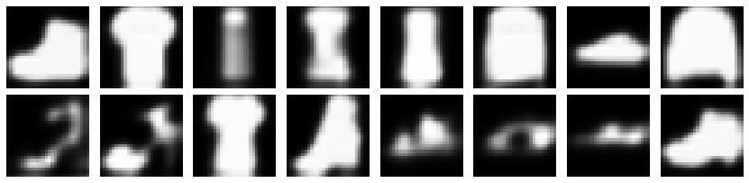

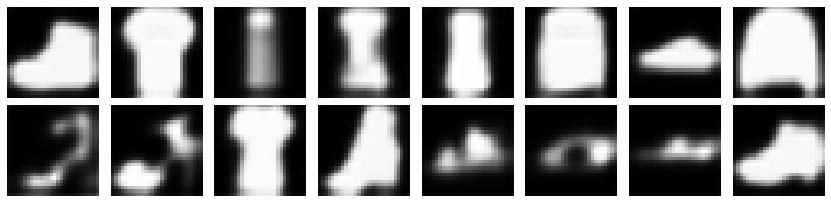

```python
# =====================================================
# DISPLAY RECONSTRUCTIONS
# =====================================================

print("Reconstructed Images:")
show_images(reconstructions[:16].cpu(), nrows=2, ncols=8, imsize=1.5)
```

```
Original Images:
```

[figure not shown]

[figure not shown]

```python
# =====================================================
# DISPLAY ORIGINAL IMAGES FOR COMPARISON
# =====================================================

print("Original Images:")
show_images(xb[:16].cpu(), nrows=2, ncols=8, imsize=1.5)
```

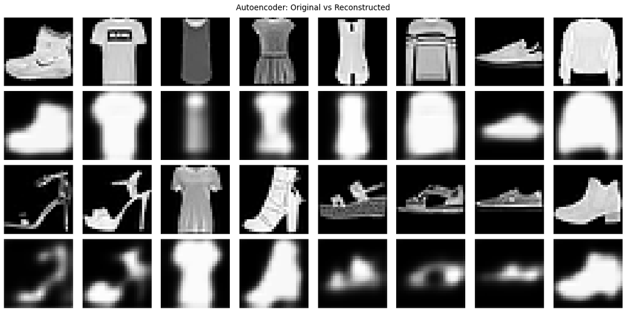

```python
# =====================================================
# SIDE-BY-SIDE COMPARISON
# =====================================================

# Let's show original and reconstruction side by side
fig, axes = plt.subplots(4, 8, figsize=(16, 8))

for i in range(8):
    # Top row: original
    show_image(xb[i].cpu(), ax=axes[0, i])
    if i == 0:
        axes[0, i].set_ylabel("Original", fontsize=12)

    # Second row: reconstruction
    show_image(reconstructions[i].cpu(), ax=axes[1, i])
    if i == 0:
        axes[1, i].set_ylabel("Reconstructed", fontsize=12)

    # Third row: another set of originals
    show_image(xb[i+8].cpu(), ax=axes[2, i])
    if i == 0:
        axes[2, i].set_ylabel("Original", fontsize=12)

    # Fourth row: their reconstructions
    show_image(reconstructions[i+8].cpu(), ax=axes[3, i])
    if i == 0:
        axes[3, i].set_ylabel("Reconstructed", fontsize=12)

plt.suptitle("Autoencoder: Original vs Reconstructed", fontsize=14)
plt.tight_layout()
```

**Observations:**

1. The reconstructions capture the **overall shape** of each clothing item
2. **Details are smoothed out** - this is expected with compression
3. The network learned to preserve the most important features
4. Some items reconstruct better than others (simpler shapes = easier)

```python
# =====================================================
# COMPUTE PER-IMAGE RECONSTRUCTION ERROR
# =====================================================

# Calculate MSE for each image individually
with torch.no_grad():
    # Compute squared differences
    sq_diff = (reconstructions - xb) ** 2
    # Average over each image (dims 1, 2, 3 are channel, height, width)
    per_image_mse = sq_diff.mean(dim=(1, 2, 3))

print("Reconstruction error (MSE) for first 16 images:")
for i in range(16):
    label = labels[yb[i].item()]
    print(f"  Image {i:2d} ({label:12s}): MSE = {per_image_mse[i]:.4f}")
```

```
Reconstruction error (MSE) for first 16 images:
  Image  0 (Ankle boot  ): MSE = 0.0240
  Image  1 (T - shirt / top): MSE = 0.0365
  Image  2 (T - shirt / top): MSE = 0.0131
  Image  3 (Dress       ): MSE = 0.0253
  Image  4 (T - shirt / top): MSE = 0.0332
  Image  5 (Pullover    ): MSE = 0.0455
  Image  6 (Sneaker     ): MSE = 0.0187
  Image  7 (Pullover    ): MSE = 0.0537
  Image  8 (Sandal      ): MSE = 0.0328
  Image  9 (Sandal      ): MSE = 0.0486
  Image 10 (T - shirt / top): MSE = 0.0151
  Image 11 (Ankle boot  ): MSE = 0.0474
  Image 12 (Sandal      ): MSE = 0.0262
  Image 13 (Sandal      ): MSE = 0.0230
  Image 14 (Sneaker     ): MSE = 0.0202
  Image 15 (Ankle boot  ): MSE = 0.0263
```

# Part 7: Understanding What the Autoencoder Learned

## The Latent Space

The middle of the autoencoder (after the encoder, before the decoder) contains a compressed representation. Let's examine it.

```python
# =====================================================
# EXAMINING THE LATENT REPRESENTATION
# =====================================================

# Create just the encoder part
encoder = nn.Sequential(
    ae[0],  # ZeroPad2d
    ae[1],  # conv(1, 2)
    ae[2],  # conv(2, 4)
).to(def_device)

# Get the latent representation of our batch
with torch.no_grad():
    latent = encoder(xb)

print(f"Input shape:  {xb.shape}")
print(f"Latent shape: {latent.shape}")
print(f"\nCompression ratio: {xb.numel() / latent.numel():.1f}x")
print(f"  Original:   {28*28} = 784 values per image")
print(f"  Compressed: {8*8*4} = 256 values per image")
```

```
Input shape:  torch.Size([256, 1, 28, 28])
Latent shape: torch.Size([256, 4, 8, 8])

Compression ratio: 3.1x
  Original:   784 = 784 values per image
  Compressed: 256 = 256 values per image
```

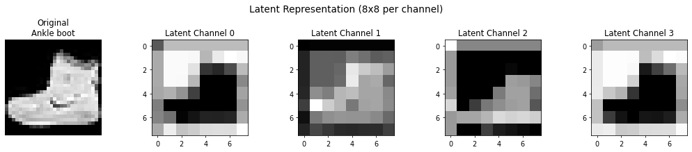

```python
# =====================================================
# VISUALIZE THE LATENT CHANNELS
# =====================================================

# Look at the 4 latent channels for one image
img_idx = 0

fig, axes = plt.subplots(1, 5, figsize=(15, 3))

# Original image
show_image(xb[img_idx].cpu(), ax=axes[0])
axes[0].set_title(f"Original\n{labels[yb[img_idx].item()]}")

# 4 latent channels
for c in range(4):
    show_image(latent[img_idx, c].cpu(), ax=axes[c+1], noframe=False)
    axes[c+1].set_title(f"Latent Channel {c}")

plt.suptitle("Latent Representation (8x8 per channel)", fontsize=14)
plt.tight_layout()
```

**Each latent channel captures different aspects of the image!** The decoder learns to combine these channels to reconstruct the original.

### 🔍 Visualize It: Walking Through the Latent Space

This is the payoff. Drag the marker around the compressed latent space (or click a cluster) and watch the decoder rebuild an image from that exact point. Moving *between* clusters morphs one garment into another — the sign of a well-organized latent space.

```python
# ============================================================================
# INTERACTIVE VISUALIZATION (self-contained) -- run this cell.
# Drag through the compressed code; watch reconstructions morph between clusters.
# The widget lives in the separate file `latent_space_explorer.html`; it is embedded here as a
# base64 data-URI iframe, so the notebook stays fully self-contained and works
# offline in Jupyter, Colab, VS Code, and the exported HTML. The iframe
# broadcasts its own content height, and the listener below resizes it to fit
# exactly -- full width, wrapped to content, with no empty space below.
# ============================================================================
```

[interactive chart not shown]

# Summary

## Key Concepts Learned

### What is an Autoencoder?

- A neural network that learns to **compress** and **reconstruct** data
- Consists of an **encoder** (compress) and **decoder** (expand)
- The **bottleneck** forces learning of essential features

### Architecture Components

| Component | Purpose | Implementation |
| --- | --- | --- |
| **Encoder** | Compress input | Conv layers with stride=2 |
| **Bottleneck** | Compressed representation | Smallest layer in the middle |
| **Decoder** | Reconstruct output | Upsample + Conv layers |
| **Sigmoid** | Bound output to [0,1] | Final activation |

### Deconvolution (Upsampling)

- Opposite of convolution with stride
- We use: **Upsample + Conv** (stable, no artifacts)
- Alternative: `ConvTranspose2d` (can cause checkerboard artifacts)

### Training Autoencoders

- **Loss function**: MSE (Mean Squared Error)
- **Target**: The input image itself!
- **Goal**: Minimize difference between input and reconstruction

### Applications

- **Dimensionality reduction** - Like PCA but non-linear
- **Denoising** - Train with noisy input, clean target
- **Anomaly detection** - High reconstruction error = unusual
- **Feature learning** - Encoder learns useful representations
- **Generative models** - VAEs extend this to generate new data

## What's Next?

In future notebooks, we'll explore:

- **Variational Autoencoders (VAEs)** - Generate new images
- **Deeper architectures** - Better reconstructions
- **Different loss functions** - Perceptual loss, adversarial loss
- **Applications** - Denoising, super-resolution, style transfer